# Projet2SerieTemporelle

mohamedhediyedes

2026-04-20

# Phase 1. Analyse exploratoire

# 1. Importation des données

```r
data <- read_excel(
  "C:/Users/MSI/Downloads/IndustrialProduction.xlsx",
  skip = 10   # 👈 très important (à ajuster)
)

print(head(data))
```

```
## # A tibble: 6 × 2
##   observation_date    IPB53122N
##   <dttm>                  <dbl>
## 1 2009-01-01 00:00:00      19.5
## 2 2009-02-01 00:00:00      21.1
## 3 2009-03-01 00:00:00      26.4
## 4 2009-04-01 00:00:00      22.4
## 5 2009-05-01 00:00:00      23.7
## 6 2009-06-01 00:00:00      28.6
```

```r
print(colnames(data))
```

```
## [1] "observation_date" "IPB53122N"
```

**Interpretation :** Les donnees sont correctement importees et correspondent a une serie temporelle liee a la production pharmaceutique aux Etats-Unis.

## 2. Construction de la serie temporelle

```r
ts_data <- ts(data$IPB53122N, start = c(2009,1), frequency = 12)
ts_data
```

```
##           Jan      Feb      Mar      Apr      May      Jun      Jul      Aug
## 2009  19.5474  21.1097  26.3598  22.3659  23.7120  28.5540  26.0627  27.7197
## 2010  31.4750  31.6933  41.4510  36.0507  37.4128  43.9694  39.2642  41.3738
## 2011  46.6407  43.2519  53.9260  45.3195  45.6454  54.1945  47.2152  49.7024
## 2012  47.7190  49.6179  59.7458  52.0254  52.5995  62.6048  54.6931  55.0130
## 2013  55.7168  51.9069  63.1691  56.9193  57.8106  66.3013  61.4811  63.5312
## 2014  67.6656  67.9790  80.8062  74.3802  76.9433  86.3089  79.8813  80.7068
## 2015  77.0749  73.3525  82.6211  74.8429  74.9948  81.8322  75.8755  77.1361
## 2016  77.6118  74.9610  84.8687  79.1239  80.9206  89.4125  86.8369  89.5674
## 2017  89.2416  91.6292 101.4255  94.4880  96.3070 104.4135  98.5706 100.9202
## 2018  98.7883  94.8774 107.5820 100.1327 101.0217 110.3560 104.9716 108.7502
## 2019  99.0498  96.2768 108.6429 101.0036 101.9688 109.6600 105.6458 110.8233
## 2020 105.0301 106.0326 113.4829 100.8206 101.5453 111.0880 109.0132 112.4132
## 2021 116.2681 111.4575 125.7093 119.1457 122.5057 126.4100 118.2749 120.6055
## 2022 116.5728 115.0137 126.2354 111.0633 111.3921 118.6623 113.8981 114.6704
```

[output cut: 19 more lines]

**Interpretation :** La serie est mensuelle (12 observations par an) et debute en janvier 2009.

## 3. Visualisation de la serie

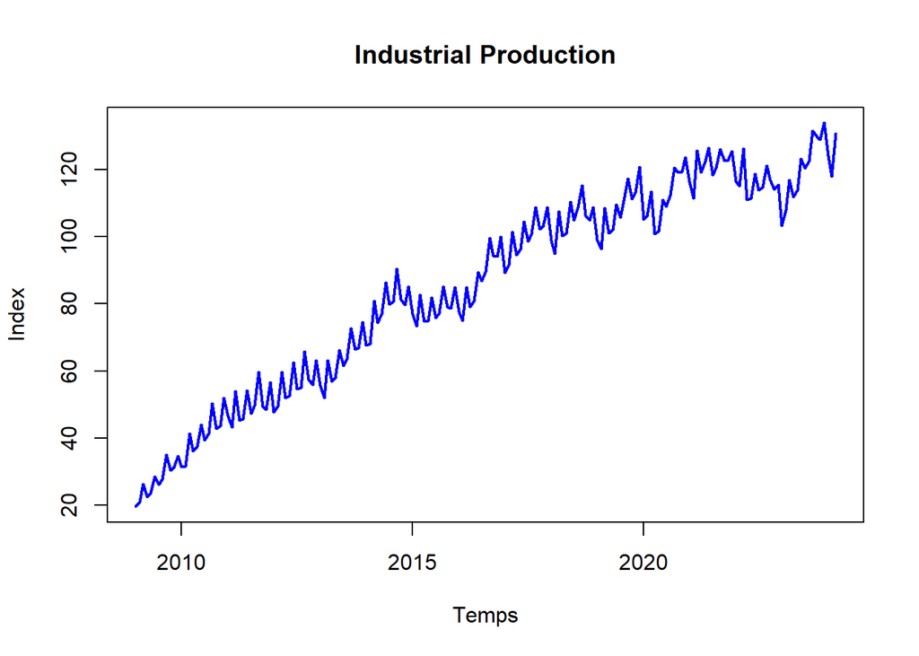

```r
plot(ts_data,
     main = "Industrial Production",
     ylab = "Index",
     xlab = "Temps",
     col = "blue",
     lwd = 2)
```

## 4. Statistiques descriptives

```r
summary(ts_data)
```

```
##    Min. 1st Qu.  Median    Mean 3rd Qu.    Max.
##   19.55   57.63   89.57   85.08  111.26  133.94
```

```r
mean(ts_data)
```

```
## [1] 85.07533
```

```r
sd(ts_data)
```

```
## [1] 30.67873
```

```r
var(ts_data)
```

```
## [1] 941.1843
```

**Interpretation :** Ces statistiques fournissent un premier resume de la position, de la dispersion et de la variabilite de la serie. —

## 5. Décomposition de la série

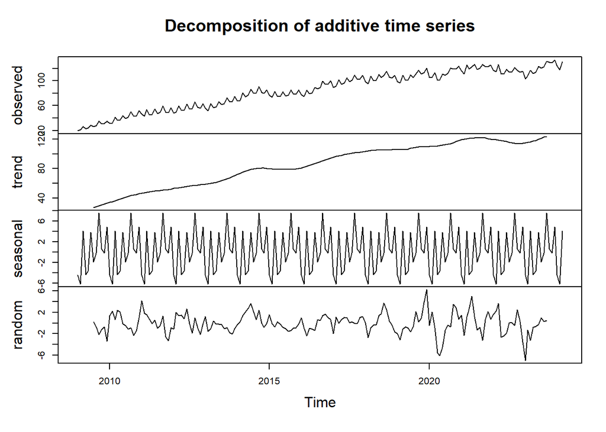

```r
t <- seq_along(ts_data)
decadd <- decompose(ts_data, type = "additive")
decmult <- decompose(ts_data, type = "multiplicative")
plot(decadd)
```

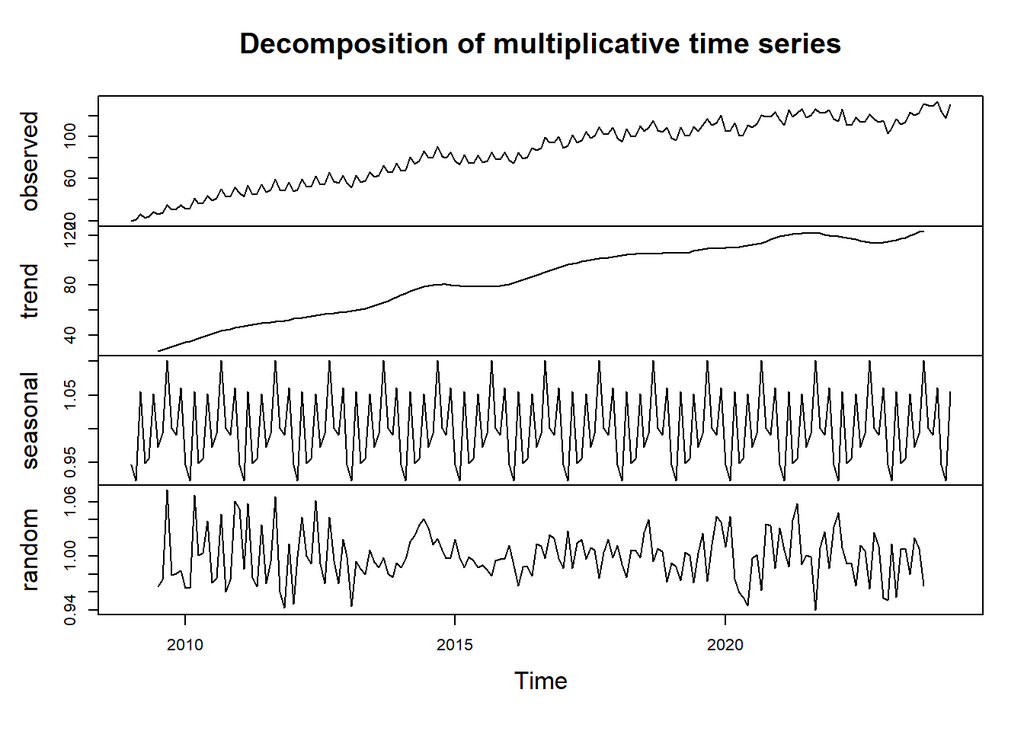

```r
plot(decmult)
```

**Interprétation :**  
La serie est decomposee en tendance, saisonnalite et residu. On observe une tendence croissante et presqueùent lineaire et une saisonnalite importante

## 6. ACF des residus de decomposition

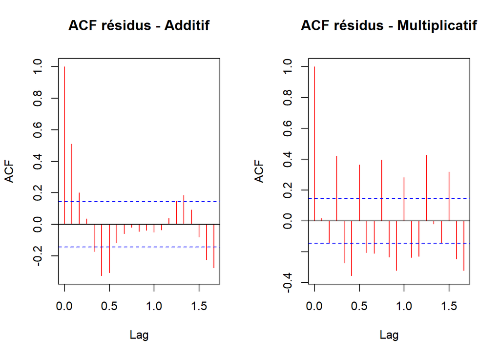

```r
par(mfrow = c(1,2))

acf(decadd$random,
    lag.max = 20,
    type = "correlation",
    plot = TRUE,
    col = "red",
    main = "ACF résidus - Additif",
    na.action=na.pass)
acf(decmult$random,
    lag.max = 20,
    type = "correlation",
    plot = TRUE,
    col = "red",
    main = "ACF résidus - Multiplicatif",
    na.action=na.pass)
```

**Interprétation :**  
Le correlogramme des residus additif presente en general moins d’autocorrelation que celui du modele multiplicatif, ce qui renforce le choix d’une structure additive.

## 7. ACF et PACF de la serie brute

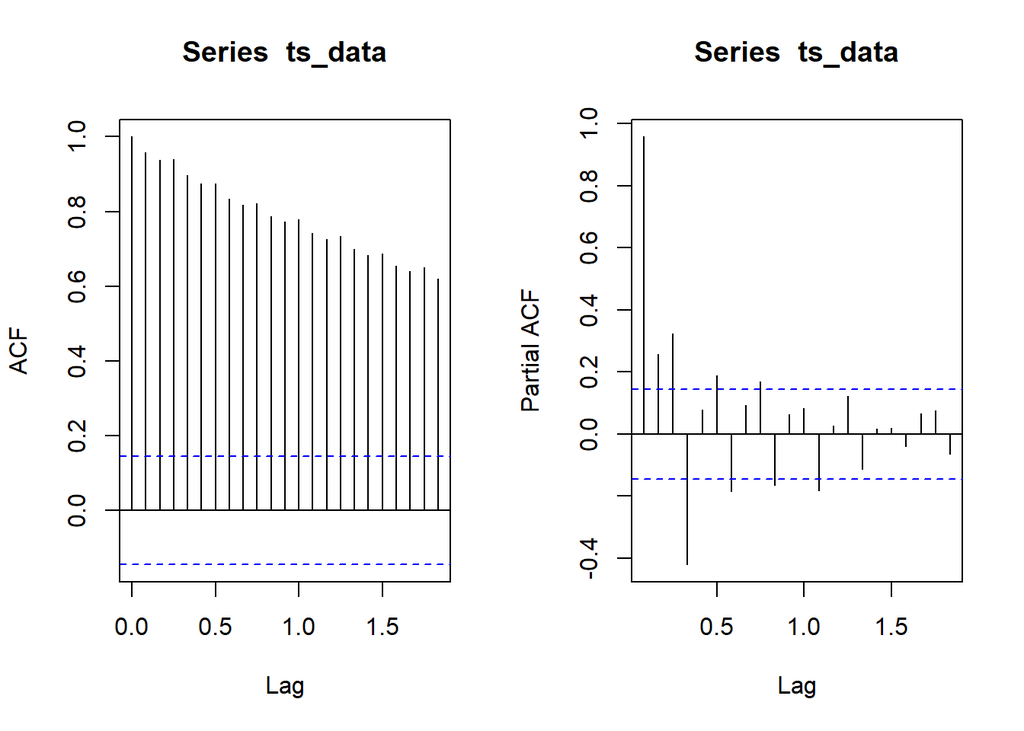

```r
par(mfrow=c(1,2))

acf(ts_data)
pacf(ts_data)
```

**Interprétation :**  
La decroissance lente de l’ACF indique une non-stationnarite (presence de tendance). La structure periodique observee soutient egalement l’existence d’une composante saisonniere.

## 8. Lag plots (dependance temporelle)

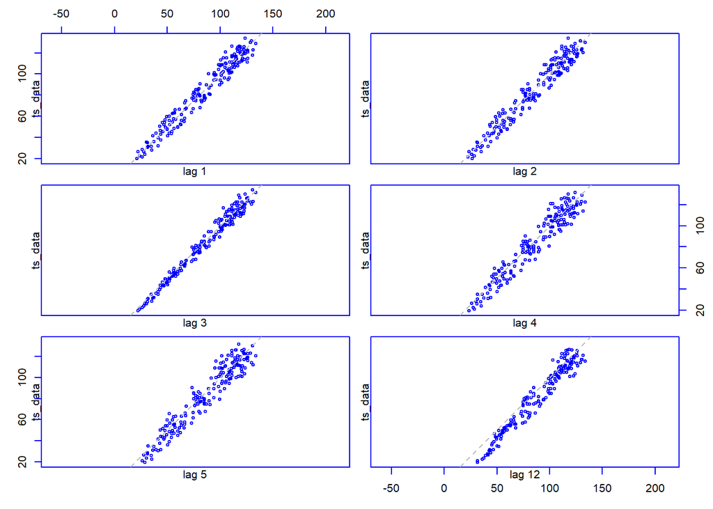

```r
lag.plot(ts_data,
         set.lags = c(1:5, 12),
         layout = c(3, 2),
         col = "blue",
         do.lines = FALSE)
```

## 9. Saisonnalite mensuelle

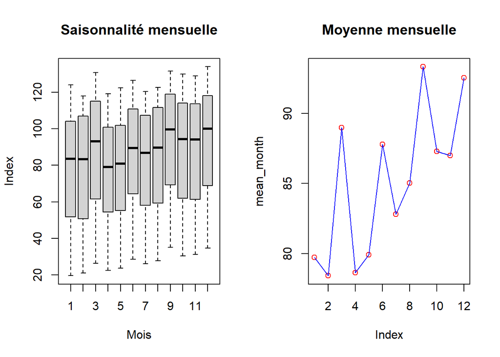

```r
par(mfrow = c(1, 2))

boxplot(ts_data ~ cycle(ts_data),
        main="Saisonnalité mensuelle",
        xlab="Mois",
        ylab="Index")

mean_month = tapply(ts_data, cycle(ts_data), mean)

plot(mean_month,
     col="red",
     main="Moyenne mensuelle")

lines(mean_month, col="blue")
```

**Interprétation :**  
On contate que Les mois de septembre (93.31) et décembre (92.52) présentent les indices les plus élevés. En revanche, février (78.43), janvier (79.73) et avril (78.64) affichent les valeurs les plus faibles.

# 10. Tests de stationnarité

```r
adf.test(ts_data)
```

```
##
##  Augmented Dickey-Fuller Test
##
## data:  ts_data
## Dickey-Fuller = -2.3466, Lag order = 5, p-value = 0.4313
## alternative hypothesis: stationary
```

**Interprétation :**  
Si la p-value est superieure a 0.05, on ne rejette pas l’hypothese nulle de non-stationnarite: la serie doit etre transformee (par exemple detrendance et/ou differenciation). notre p_value = 0.4313

# Phase 2. Modelisation de la tendance et de la saisonnalite

## 1. Ajustement de la tendance

### 1.1. Moyenne mobile

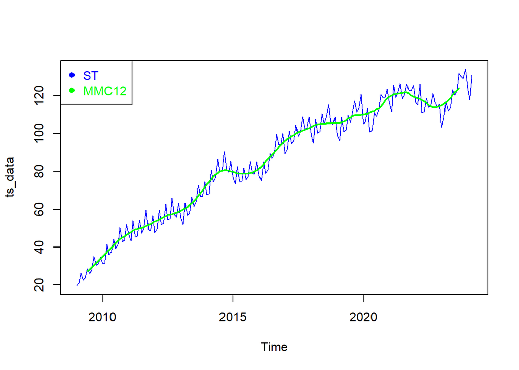

```r
MMC12 <- filter(ts_data, filter = rep(1/12, 12), method = "convolution", sides = 2)
plot(ts_data, col="blue", lwd=1)
lines(MMC12, col="green", lwd=2)
legend(x="topleft",legend=c("ST", "MMC12"), text.col=c("blue","green"),
pch=c(16,16), col=c("blue","green"))
```

**Interprétation :**  
La moyenne mobile lisse la serie et facilite la lecture de la tendance de fond.

### 1.2. Regression lineaire

```r
modelRL <- lm(ts_data ~ t)
summary(modelRL)
```

```
##
## Call:
## lm(formula = ts_data ~ t)
##
## Residuals:
##      Min       1Q   Median       3Q      Max
## -24.9493  -4.9350  -0.2682   5.7103  18.2411
##
## Coefficients:
##             Estimate Std. Error t value Pr(>|t|)
## (Intercept) 33.60524    1.18087   28.46   <2e-16 ***
## t            0.55946    0.01113   50.26   <2e-16 ***
## ---
## Signif. codes:  0 '***' 0.001 '**' 0.01 '*' 0.05 '.' 0.1 ' ' 1
##
## Residual standard error: 7.955 on 181 degrees of freedom
## Multiple R-squared:  0.9331, Adjusted R-squared:  0.9328
## F-statistic:  2526 on 1 and 181 DF,  p-value: < 2.2e-16
```

**Interprétation :**  
Le modele lineaire capte une tendance globale simple. La significativite des coefficients se juge a partir des p-values du resume du modele.

### 1.3. Regression polynomiale de degre 2

```r
modelPoly2 <- lm(ts_data ~ t + I(t^2))
summary(modelPoly2)
```

```
##
## Call:
## lm(formula = ts_data ~ t + I(t^2))
##
## Residuals:
##      Min       1Q   Median       3Q      Max
## -18.2153  -4.0683  -0.3013   4.1396  13.3882
##
## Coefficients:
##               Estimate Std. Error t value Pr(>|t|)
## (Intercept) 21.4319303  1.3163048   16.28   <2e-16 ***
## t            0.9542676  0.0330310   28.89   <2e-16 ***
## I(t^2)      -0.0021457  0.0001739  -12.34   <2e-16 ***
## ---
## Signif. codes:  0 '***' 0.001 '**' 0.01 '*' 0.05 '.' 0.1 ' ' 1
##
## Residual standard error: 5.871 on 180 degrees of freedom
## Multiple R-squared:  0.9638, Adjusted R-squared:  0.9634
## F-statistic:  2395 on 2 and 180 DF,  p-value: < 2.2e-16
```

**Interprétation :**  
Le terme quadratique permet une courbure de la tendance, donc un ajustement potentiellement plus flexible que le modele lineaire.

## 2. Comparaison visuelle des tendances

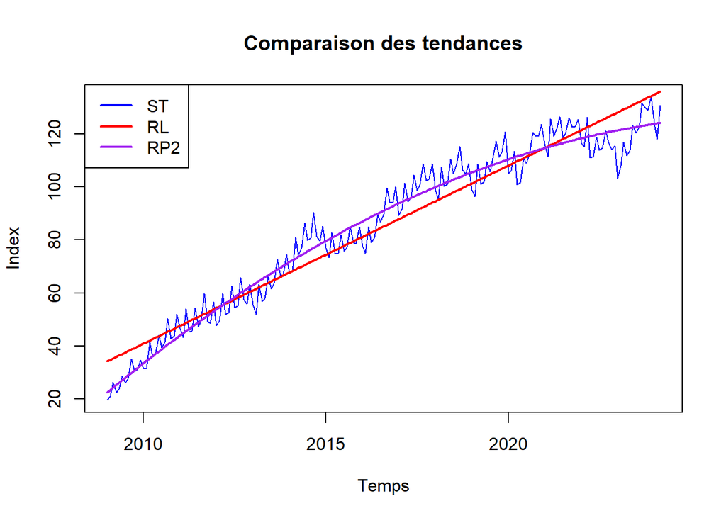

```r
par(mfrow=c(1,1))

x_time <- as.numeric(time(ts_data))
y_data <- as.numeric(ts_data)

### Série brute avec les différentes tendances
plot(x_time,
     y_data,
     type="l",
     col="blue",
     main="Comparaison des tendances",
     ylab="Index",
     xlab="Temps")

lines(x_time,
     as.numeric(fitted(modelRL)),
      col="red",
      lwd=2)

lines(x_time,
     as.numeric(fitted(modelPoly2)),
      col="purple",
      lwd=2)

legend("topleft",legend = c("ST", "RL", "RP2"),col = c("blue","red","purple"),lwd = 2)
```

```r
cor(ts_data, fitted(modelRL))
```

```
## [1] 0.965992
```

```r
cor(ts_data, fitted(modelPoly2))
```

```
## [1] 0.9817242
```

**Interprétation :**  
Dans le modele linéaire est ajusté sur la série brute et tente d’expliquer simultanément la tendance et la variabilité saisonnière et conduit mécaniquement à un coefficient de détermination relativement (𝑅2 = 0.9331).

Dans le modele polynomial de degres 2 est ajusté sur la série brute et tente d’expliquer simultanément la tendance et la variabilité saisonnière et conduit mécaniquement à un coefficient de détermination relativement (𝑅2 = 0.9638).

on choisis le modele ayant le r_squared la plus grande alors le meilleur modele est le polynomial de degres 2

## 3. Estimation de la saisonnalite apres retrait de la tendance

### 3.1. Cas de la regression lineaire

```r
saisonnaliteResidusRL <- ts_data - fitted(modelRL)

saisonnaliteResidusRLstd <- as.numeric(scale(saisonnaliteResidusRL))
saisonnaliteResidusRLstd <- ts(saisonnaliteResidusRLstd,
                               start = start(ts_data),
                               frequency = frequency(ts_data))

t_time <- as.numeric(time(ts_data))


modeleSaisRL <- lm(saisonnaliteResidusRLstd ~
                     cos(2*pi*t_time/12) + cos(4*pi*t_time/12) +
                     sin(2*pi*t_time/12) + sin(4*pi*t_time/12))

summary(modeleSaisRL)
```

```
##
## Call:
## lm(formula = saisonnaliteResidusRLstd ~ cos(2 * pi * t_time/12) +
##     cos(4 * pi * t_time/12) + sin(2 * pi * t_time/12) + sin(4 *
##     pi * t_time/12))
##
## Residuals:
##      Min       1Q   Median       3Q      Max
## -2.35652 -0.54719  0.02413  0.54136  1.83440
##
## Coefficients:
##                         Estimate Std. Error t value Pr(>|t|)
## (Intercept)              0.16659    0.06244   2.668  0.00834 **
## cos(2 * pi * t_time/12)  0.63581    0.08480   7.498 2.95e-12 ***
## cos(4 * pi * t_time/12) -0.21152    0.08732  -2.422  0.01642 *
## sin(2 * pi * t_time/12)  0.40585    0.09097   4.461 1.44e-05 ***
## sin(4 * pi * t_time/12) -0.11073    0.08617  -1.285  0.20047
## ---
## Signif. codes:  0 '***' 0.001 '**' 0.01 '*' 0.05 '.' 0.1 ' ' 1
##
## Residual standard error: 0.8109 on 178 degrees of freedom
## Multiple R-squared:  0.3569, Adjusted R-squared:  0.3425
## F-statistic:  24.7 on 4 and 178 DF,  p-value: 2.817e-16
```

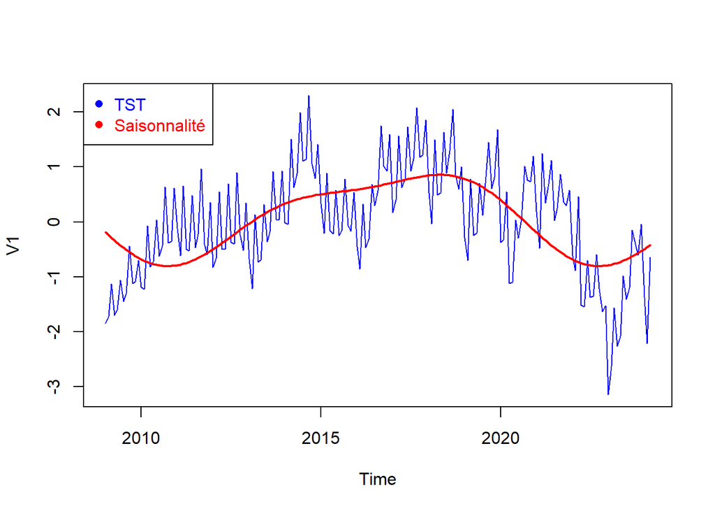

```r
plot(saisonnaliteResidusRLstd, col="blue", ylab="V1")
points(time(ts_data), fitted(modeleSaisRL), type="l", col="red", lwd=2)
legend(x="topleft",legend=c("TST", "Saisonnalité"),
text.col=c("blue","red"),
pch=c(16,16), col=c("blue","red"))
```

### 3.2. Cas de la regression polynomiale degre 2

```r
saisonnaliteResidusPoly2 <- ts_data - fitted(modelPoly2)

saisonnaliteResidusPoly2std <- as.numeric(scale(saisonnaliteResidusPoly2))
saisonnaliteResidusPoly2std <- ts(saisonnaliteResidusPoly2std,
                                  start = start(ts_data),
                                  frequency = frequency(ts_data))

modeleSaispoly2 <- lm(saisonnaliteResidusPoly2std ~
                        cos(2*pi*t_time/12) + cos(4*pi*t_time/12) +
                        sin(2*pi*t_time/12) + sin(4*pi*t_time/12))

summary(modeleSaispoly2)
```

```
##
## Call:
## lm(formula = saisonnaliteResidusPoly2std ~ cos(2 * pi * t_time/12) +
##     cos(4 * pi * t_time/12) + sin(2 * pi * t_time/12) + sin(4 *
##     pi * t_time/12))
##
## Residuals:
##      Min       1Q   Median       3Q      Max
## -3.07824 -0.65353  0.02286  0.73905  2.56097
##
## Coefficients:
##                          Estimate Std. Error t value Pr(>|t|)
## (Intercept)             -0.002216   0.076619  -0.029   0.9770
## cos(2 * pi * t_time/12) -0.117350   0.104052  -1.128   0.2609
## cos(4 * pi * t_time/12) -0.057852   0.107144  -0.540   0.5899
## sin(2 * pi * t_time/12)  0.242050   0.111621   2.169   0.0314 *
## sin(4 * pi * t_time/12)  0.010273   0.105738   0.097   0.9227
## ---
## Signif. codes:  0 '***' 0.001 '**' 0.01 '*' 0.05 '.' 0.1 ' ' 1
##
## Residual standard error: 0.995 on 178 degrees of freedom
## Multiple R-squared:  0.03182,    Adjusted R-squared:  0.01006
## F-statistic: 1.462 on 4 and 178 DF,  p-value: 0.2155
```

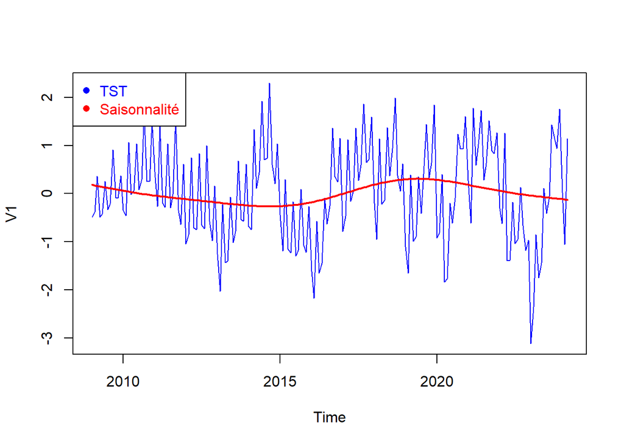

```r
plot(saisonnaliteResidusPoly2std, col="blue", ylab="V1")
points(time(ts_data), fitted(modeleSaispoly2), type="l", col="red", lwd=2)
legend(x="topleft", legend=c("TST", "Saisonnalité"),
       text.col=c("blue","red"),
       pch=c(16,16), col=c("blue","red"))
```

**Interprétation :**  
La saisonnalite est estimee de la meme facon apres retrait de la tendance quadratique, ce qui permet de comparer les residus entre modeles.

### 3.3. Comparaison des deux modeles

```r
AIC(modeleSaisRL, modeleSaispoly2)
```

```
##                 df      AIC
## modeleSaisRL     6 449.5306
## modeleSaispoly2  6 524.4112
```

### 3.4. Comparaison tendance + saisonnalité

```r
cor(ts_data, fitted(modeleSaispoly2) + fitted(modelPoly2))
```

```
## [1] 0.9819092
```

## 4. Analyse des residus apres retrait de la saisonnalite

### 4.1. Residus du modele lineaire

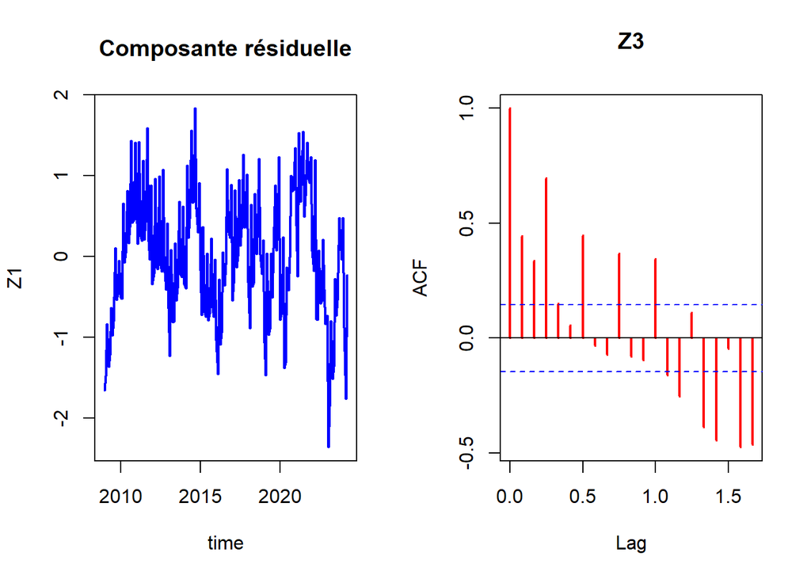

```r
Z3 = saisonnaliteResidusRLstd - fitted(modeleSaisRL)
par(mfrow = c(1,2))
plot.ts(Z3, xlab="time",ylab=" Z1 ", lwd = 2,
main="Composante résiduelle", col="blue")
acf(Z3, lag.max = 20, type = c("correlation"),
plot = TRUE, col="red", main = "Z3", lwd = 2,
na.action = na.pass)
```

**Interprétation :**  
Si des pics significatifs apparaissent dans l’ACF, les residus conservent une structure temporelle.

### 4.2. Residus du modele polynomial degre 2

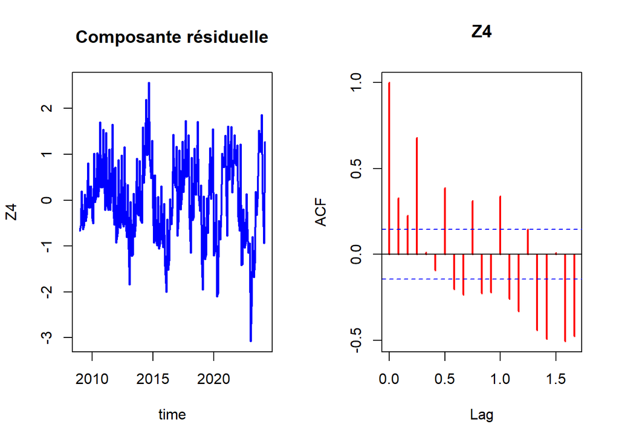

```r
Z4 = saisonnaliteResidusPoly2std - fitted(modeleSaispoly2)
par(mfrow = c(1,2))
plot.ts(Z4, xlab="time", ylab=" Z4 ", lwd = 2,
main="Composante résiduelle", col="blue")
acf(Z4, lag.max = 20, type = "correlation",
plot = TRUE, col="red", main = "Z4", lwd = 2,
na.action = na.pass)
```

**Interprétation :**  
Le correlogramme permet de verifier si le modele a bien capture la dependance temporelle principale.

## 5. Test de stationnarite des residus (Z4)

```r
test = adf.test(Z4)
test
```

```
##
##  Augmented Dickey-Fuller Test
##
## data:  Z4
## Dickey-Fuller = -3.8434, Lag order = 5, p-value = 0.01834
## alternative hypothesis: stationary
```

**Interprétation :**  
La p-valeur est inférieure à 0.05, on rejette H0 de non-stationnarité, ce qui confirme que Z4 est stationnaire.

**Finalement, on teste si la série résiduelle correspond à un bruit blanc. Pour ce faire, on peut procéder de deux manières :**

1. On trace la fonction d’autocorrélation (ACF) et on vérifie l’absence d’autocorrélation significative.
2. On applique le test de Ljung-Box en utilisant la commande Box.test()

## 6. Verification du bruit blanc sur Z4 (serie residuelle stationnaire)

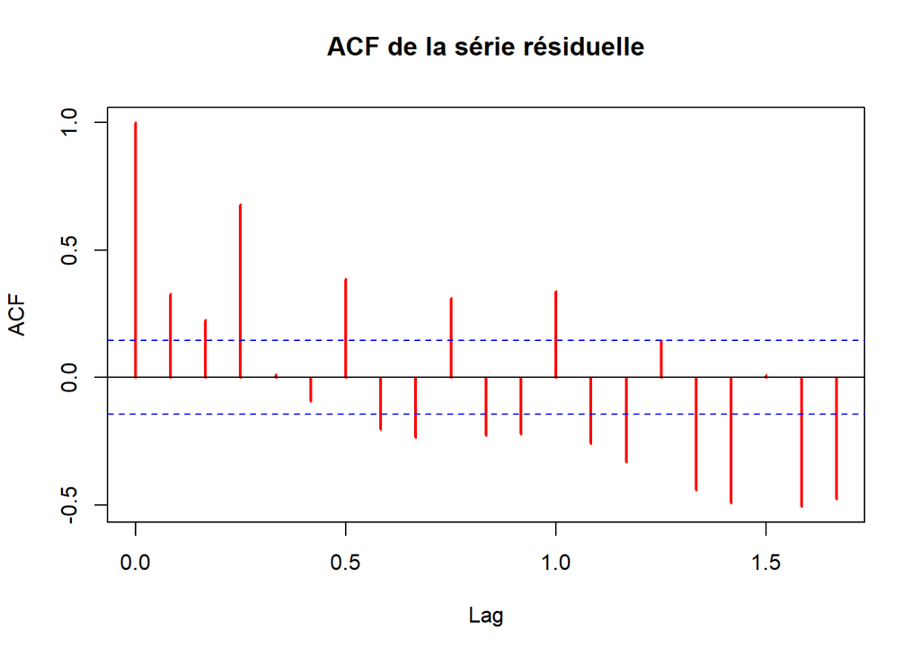

```r
acf(Z4, lag.max=20, col='red', main="ACF de la série résiduelle", lwd=2)
```

```r
testB = Box.test(Z4, lag=20, type = "Ljung-Box")
testB
```

```
##
##  Box-Ljung test
##
## data:  Z4
## X-squared = 455.41, df = 20, p-value < 2.2e-16
```

**Interprétation :**  
L’ACF montre une autocorrélation, et le test de Ljung-Box, avec une p-valeur inférieure à 0.05, indique que la série n’est pas un bruit blanc. La série résiduelle présente encore une structure, ce qui indique que toute l’information n’a pas été capturée.Il convient donc de modéliser la série stationnaire obtenue à l’aide d’un modèle ARMA

# Phase 3. Modelisation ARIMA et prevision

## 1. Identification automatique du modele

```r
ARIMA = auto.arima(Z4, d=0, D=0, seasonal=FALSE, trace=TRUE)
```

```
##
##  Fitting models using approximations to speed things up...
##
##  ARIMA(2,0,2)            with non-zero mean : 458.8288
##  ARIMA(0,0,0)            with non-zero mean : 516.4779
##  ARIMA(1,0,0)            with non-zero mean : 497.8036
##  ARIMA(0,0,1)            with non-zero mean : 471.2697
##  ARIMA(0,0,0)            with zero mean     : 514.4333
##  ARIMA(1,0,2)            with non-zero mean : 469.49
##  ARIMA(2,0,1)            with non-zero mean : 486.2915
##  ARIMA(3,0,2)            with non-zero mean : Inf
##  ARIMA(2,0,3)            with non-zero mean : 386.5773
##  ARIMA(1,0,3)            with non-zero mean : 390.0598
##  ARIMA(3,0,3)            with non-zero mean : Inf
##  ARIMA(2,0,4)            with non-zero mean : 344.9129
##  ARIMA(1,0,4)            with non-zero mean : 390.8318
##  ARIMA(3,0,4)            with non-zero mean : Inf
##  ARIMA(2,0,5)            with non-zero mean : Inf
##  ARIMA(1,0,5)            with non-zero mean : 366.0007
##  ARIMA(3,0,5)            with non-zero mean : Inf
##  ARIMA(2,0,4)            with zero mean     : 342.9868
##  ARIMA(1,0,4)            with zero mean     : 388.6855
##  ARIMA(2,0,3)            with zero mean     : 384.4392
##  ARIMA(3,0,4)            with zero mean     : Inf
##  ARIMA(2,0,5)            with zero mean     : Inf
##  ARIMA(1,0,3)            with zero mean     : 387.9465
##  ARIMA(1,0,5)            with zero mean     : 364.0414
##  ARIMA(3,0,3)            with zero mean     : Inf
##  ARIMA(3,0,5)            with zero mean     : Inf
##
##  Now re-fitting the best model(s) without approximations...
##
##  ARIMA(2,0,4)            with zero mean     : 342.9726
##
##  Best model: ARIMA(2,0,4)            with zero mean
```

**Interprétation :**  
selon le test de ARMA on a trouver que le meilleur model est : ARIMA(2,0,4) with zero mean

## 2. Estimation du modele retenu et diagnostics

```r
ARMA = Arima(Z4, order = c(2,0,4), include.mean = FALSE)
summary(ARMA)
```

```
## Series: Z4
## ARIMA(2,0,4) with zero mean
##
## Coefficients:
##           ar1      ar2     ma1     ma2     ma3     ma4
##       -0.7513  -0.6463  1.2407  1.0967  1.0639  0.5694
## s.e.   0.0792   0.0932  0.0812  0.1123  0.0719  0.0585
##
## sigma^2 = 0.3574:  log likelihood = -164.17
## AIC=342.33   AICc=342.97   BIC=364.8
##
## Training set error measures:
##                       ME      RMSE       MAE      MPE     MAPE    MASE
## Training set 1.84909e-05 0.5879846 0.4621578 50.30397 135.8748 0.52383
##                   ACF1
## Training set 0.1525506
```

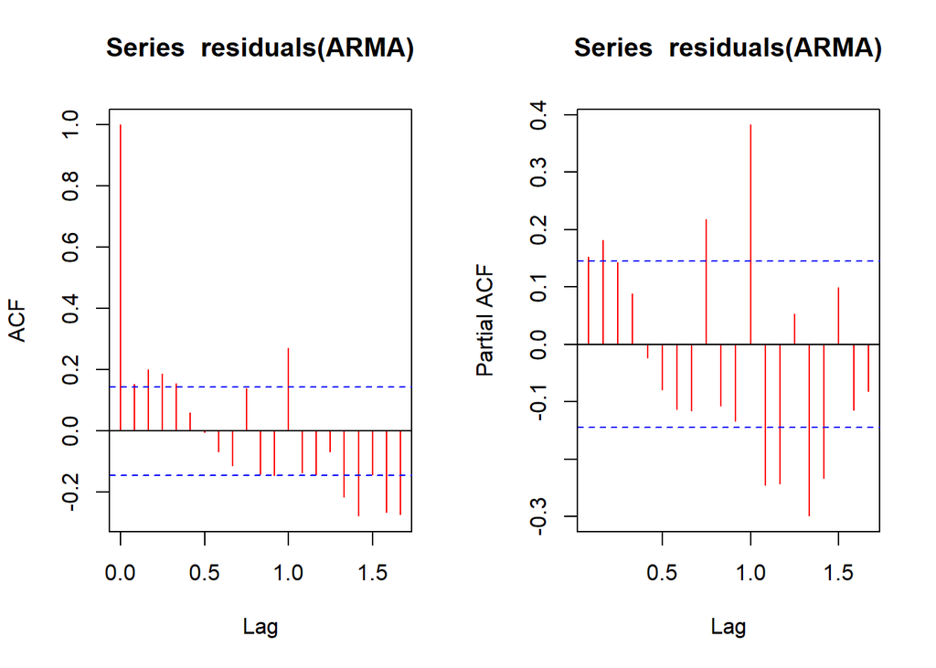

```r
par(mfrow=c(1, 2))

### Diagnostic du modele ARIMA
acf(residuals(ARMA), lag.max = 20, type = "correlation", plot = TRUE, col="red")
pacf(residuals(ARMA), lag.max = 20, plot = TRUE, col="red")
```

```r
# Tracé de la serie et de l'ajustement
plot(Z4, xlab="Time", ylab="Z4",main="Série résiduelle",col="blue", lwd=1, type="l")
lines(fitted(ARMA), col="red", lwd=1)
# Ajouter la légende
legend("topleft",
legend = c("Z4 originale", "Z4 estimée"),
col = c("blue", "red"),
lwd = 2,
bg = "gray90")

testBox = Box.test(residuals(ARMA), lag = 24, type = "Ljung-Box", fitdf = 6)
testBox
```

[output not shown]

```
##
##  Box-Ljung test
##
## data:  residuals(ARMA)
## X-squared = 146.27, df = 18, p-value < 2.2e-16
```

```r
testJB = jarque.bera.test(residuals(ARMA))
testJB
```

```
##
##  Jarque Bera Test
##
## data:  residuals(ARMA)
## X-squared = 18.901, df = 2, p-value = 7.865e-05
```

```
##
##  Ljung-Box test
##
## data:  Residuals from ARIMA(2,0,4) with zero mean
## Q* = 146.27, df = 18, p-value < 2.2e-16
##
## Model df: 6.   Total lags used: 24
```

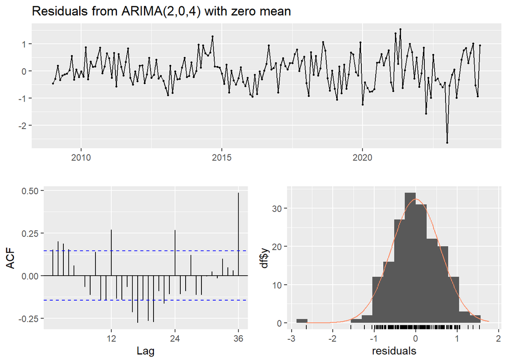

```r
checkresiduals(ARMA)
```

**Interprétation :**  
Après l’estimation du modèle ARIMA, plusieurs outils de diagnostic ont été utilisés afin d’évaluer la qualité de l’ajustement du modèle.

Tout d’abord, l’analyse des fonctions d’autocorrélation (ACF) et d’autocorrélation partielle (PACF) des résidus montre la présence de certaines autocorrélations significatives. Cela signifie que les résidus ne sont pas totalement indépendants et qu’il subsiste encore une structure temporelle non capturée par le modèle.

Ensuite, le test de Ljung-Box appliqué aux résidus fournit une p-valeur inférieure au seuil de signification de 5 %. On rejette donc l’hypothèse nulle d’absence d’autocorrélation, ce qui indique que les résidus ne correspondent pas à un bruit blanc.

Par ailleurs, le test de Jarque-Bera permet d’évaluer la normalité des résidus. La p-valeur obtenue étant également inferieur à 0,05, l’hypothèse de normalité des résidus est rejete .

Ainsi, l’ensemble des diagnostics (ACF, PACF, test de Ljung-Box et test de Jarque-Bera) montre que les résidus du modèle ARIMA estimé ne se comportent pas comme un bruit blanc. Cela signifie que le modèle ne capture pas entièrement la dynamique de la série temporelle et qu’une amélioration du modèle pourrait être envisagée.

## 3. Previsions a 12 periodes

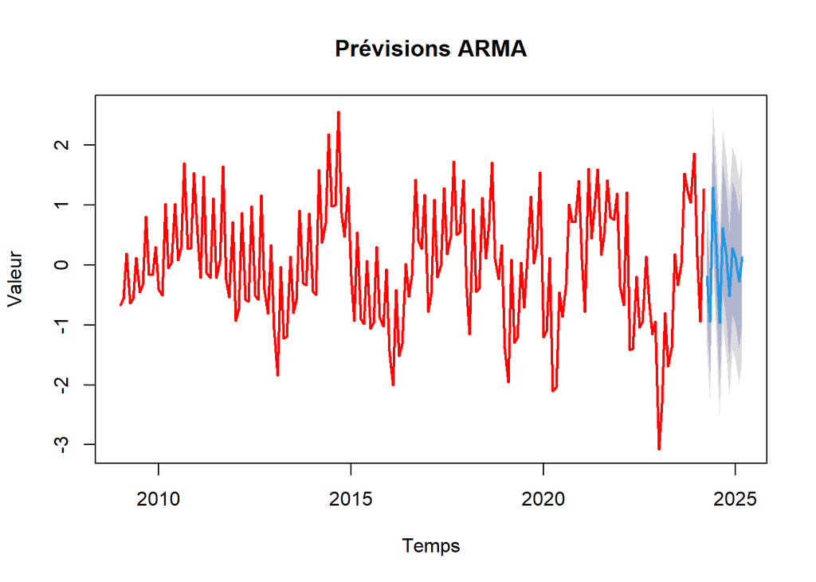

```r
prev = forecast(ARMA, h = 12)
plot(prev, type = "l", col = "red", lwd = 2,
     main = "Prévisions ARMA", xlab = "Temps", ylab = "Valeur")
```

**Interprétation :**  
Le graphique presente les previsions a court terme ainsi que les intervalles d’incertitude associes.